# Bruhn_C11_5

2a. $f_{scr}$ および $k$ について上部外板パネルをチェックする。

Fig. C11.47の特性と付加荷重を用いて、式(74)より $R_c$ を求める。外板は早期に座屈するため、外板圧縮応力は「仮想的」なものとなるが、相互作用に適した適切な定数 $B$ を与える。上部ロンジロンから上面へ2/3上がった位置での $f_{Cskin}$ が、支配的な圧縮座屈を決定するものと仮定する。

$$_{f_{Cskin}} = \frac{MZ}{I} = \frac{-2,135,000(27.7)}{1895} = -31,200
\text{ psi (comp.)}$$

$$_{f_s} = \frac{T}{2At} = \frac{600,000}{2(2830)(.025)} = 4240 \text{
psi}$$

次に、式(73)より、

$$B = \frac{f_c}{f_s} = \frac{31,200}{4240} = 7.35$$

この上部パネル（長さ $d = 5"$ 、幅 $h = 41.8"$ 、半径 $R = 30"$ ）について、限界純せん断座屈応力および圧縮座屈応力は、第C8章の座屈方程式から求めることができる。

第C8章より、このパネル寸法に対して $k_c = 10$ 、 $k_s = 12.83$ となり、したがって

$$_{F_{Ccr}} = \frac{\pi^2 \times 10 imes 10,300,000}{12(1 - .3^2)}
\left( \frac{.025}{5} \right)^2 = 2310 \text{ psi}$$

$$_{F_{Scr}} = \frac{\pi^2 \times 12.83 \times 10,300,000}{12(1 - .3^2)}
\left( \frac{.025}{5} \right)^2 = 2980 \text{ psi}$$

ゆえに、式(72)より、

$$A = \frac{F_{Ccr}}{F_{Scr}} = \frac{2310}{2980} = .774$$

次に、式(74)より、

$$R_c = \frac{-\frac{B}{A} + \sqrt{\left(\frac{B}{A}\right)^2 + 4}}{2} =
\frac{-\frac{7.35}{.774} + \sqrt{\left(\frac{7.35}{.774}\right)^2 +
4}}{2} = .105$$

および

$$f_{s_{cr}} = R_c F_{S_{cr}} = .105(2980) = 313 \text{ psi}$$

3a. 荷重比 $\frac{f_s}{f_{s_{cr}}}$ は、

$$\frac{f_s}{f_{s_{cr}}} = \frac{4240}{313} = 13.54$$

4a. 次に、(3a)とFig. C11.19より、 $k$ は以下のようになる。

$$\frac{300 t h}{R d} = \frac{300(.025)}{30} (2)^* = .5$$

$$k = .81$$

次に、サイドパネルについてステップ2a〜4aを繰り返す。これには、複合せん断および圧縮下での座屈基準として機能する任意の相互作用が含まれる。

2b. サイドパネルの上部（上部ロンジロン）および下部（下部ロンジロン）の応力は、それぞれ -37,200 (圧縮) および 14,800 (引張) である。これにより、平均「仮想」応力は軸力で -11,200、曲げ応力（等価）で $\pm 26,000$ psi となる。サイドパネルの実際の減少座屈応力は、これらの軸応力と曲げ応力の相互作用から得ることができる。

別の方法として、曲げ応力の影響を考慮するために、平均値の安全側（高い側）で「重み付け」された軸応力のみを任意に使用することもできる。この問題では、平均値 -11,200 と最大値 -37,200 の中間値である圧縮応力値を使用する。

したがって、

$$f_c = \frac{-11,200 - 37,200}{2} = -24,200 \text{ psi}$$

次に、 $f_s = 11,780$ であるため、

$$B = \frac{f_c}{f_s} = \frac{24,200}{11,780} = 2.05$$

そして、前と同様に、

$$A = .774 \quad \left( = \frac{F_{Ccr}}{F_{Scr}} \right)$$

したがって、

$$R_c = \frac{-\frac{2.05}{.774} + \sqrt{\left(\frac{2.05}{.774}\right)^2
+ 4}}{2} = .335$$

および

$$f_{s_{cr}} = R_c F_{S_{cr}} = .335(2980) = 998 \text{ psi}$$

3b. 荷重比は、

$$\frac{f_s}{f_{s_{cr}}} = \frac{11,780}{998} = 11.8$$

4b. Fig. C11.19から、(3b)の11.8を用いて、

$$k = .79$$

5. 上部ロンジロン応力は、式(104)から得ることができる。
- $\frac{h}{d} \ge 2.0$ であるため、2.0を使用する（C11.33ページを参照）。

$$f_L = f_p \frac{k_1 f_{S_1} \cot \alpha_1}{\frac{2 A_L}{h_1 t_1} +
.5(1-k_1)R_c} - \frac{k_2 f_{S_2} \cot \alpha_2}{\frac{2 A_L}{h_2 t_2} +
.5(1-k_2)R_c}$$

$$= -37,200 - \frac{.81(4240) \cot \alpha_1}{\frac{2(.6)}{(41.8)(.025)} +
.5(1-.81)(.105)} - \frac{.79(11,780) \cot
\alpha_2}{\frac{2(.6)}{52.4(.025)} + .5(1-.79)(.335)}$$

$$= -37,200 - 2970 \cot \alpha_1 - 9810 \cot \alpha_2$$

6a. 上部外板を支持するリングの応力は、式(105)から得られる。

まず、

$$A_{RG_e} = \frac{A_{RG}}{1 + \left(\frac{e}{\rho}\right)^2} =
\frac{.0787}{1 + \left(\frac{.75}{.58}\right)^2} = .0285$$

次に、

$$f_{RG} = \frac{.81(4240) \tan \alpha_1}{\frac{.0285}{5(.025)} +
.5(1-.81)} = 10,600 \tan \alpha_1$$

前述のように、これはフレームの各側の上部パネルが同じせん断応力を持つことを前提としている。

6b. サイドパネルを支持するリングの応力も同様に、

$$f_{RG} = \frac{.79(11780) \tan \alpha_2}{\frac{.0285}{5(.025)} +
.5(1-.79)} = 27,900 \tan \alpha_2$$

上記の方程式における $\alpha_1$ および $\alpha_2$ は、それぞれ上部パネルおよびサイドパネルを指す。

7. 対角引張角。

上部パネルの圧縮は非常に大きいため、 $\alpha_1$ は合理的に $45^{\circ}$ とみなすことができる。

サイドパネルについても、上部においては同様である可能性が高いが、これは逐次近似法と式(106)、(105)、(104)および(94)を用いてチェックされる。

$\alpha = 44^{\circ}$ （および $\alpha = 45^{\circ}$ ）と仮定する。Fig. C11.36と上記の方程式から、

$$\epsilon = 1.88 \left(\frac{f_s}{E}\right) = 1.88
\left(\frac{11,780}{10.3 \times 10^6}\right) = .00215$$

$$\epsilon_L = \frac{f_L}{E} = -.00361 - .00028(1.19) - .00095(1.19) =
-.00507$$

$$\epsilon_{RG} = \frac{f_{RG}}{E} = \frac{-27,900(.967)}{10.3 \times
10^6} = -.00262$$

次に、

$$\tan^2 \alpha_2 = \frac{\epsilon_1 - \epsilon_L}{\epsilon_1 -
\epsilon_{RG} + \frac{1}{8}\left(\frac{d}{R}\right)^2 \tan^2 \alpha}$$

$$= \frac{.00215 - (-.00507)}{.00215 - (-.00262) +
\frac{1}{8}\left(\frac{5}{30}\right)^2(.705)} = 1.00$$

したがって、 $\alpha_2 = 45^{\circ}$ となり、これは仮定した $44^{\circ}$ に非常に近い。 $\alpha_2 = 45^{\circ}$ とする。これは、重大な圧縮応力（またはひずみ）が存在すると、 $\alpha$ が $45^{\circ}$ に近づくという記述を裏付けている。

有意な平均軸ひずみ（または応力）が存在しなかった場合、 $\alpha$ は純せん断に基づいているFig. C11.45から得ることができる。これを上記のサイドパネルに使用すると、たとえば次のようになる。

$$\frac{E}{f_s}\left(\frac{d}{R}\right)^2 = \frac{10.3 \times
10^6}{11,780}\left(\frac{5}{30}\right)^2 = 23.5$$

$$\frac{A_{RG_e}}{dt} = .228 ; \quad \frac{A_L}{ht} =
\frac{.6}{52.3(.025)} = .459$$

次に、上記のパラメータを使用してFig. C11.45から、

$$\alpha = 36^{\circ} \text{ （圧縮なしの場合）}$$

したがって、以前に計算されたように、圧縮の影響は、単純化のためにしばしば仮定されるように、 $\alpha$ を $45^{\circ}$ に強制する上で重要である。

8. 上部外板パネルおよびサイド外板パネルの上部について $\alpha$ が $45^{\circ}$ として確立されたので、応力が利用可能になり（(5)および(6)から）、強度チェックを行うことができる。
1. ロンジロン:

$$f_p = -37,200 ; \quad f_{D.T.} = -2970(1.0) - 9810(1.0) = -12,780$$

$$F_{cc} = 65,000$$

Fig. C11.38および図中の「C」の公式を使用して、

$$F_L = N \times C = 27,700(1.28) = 35,400$$

次に、提案されている相互作用方程式を使用して、

$$\frac{37,200}{65,000} + \frac{12,780}{35,400} = .935 < 1.0 \text{
（十分）}$$

2. リング:

サイドパネル外板の下のリングが最も重要になる（ $f_s$ がより大きいため）：

$$f_{RG} = 27,900(1.0) = 27,900$$

$$k^{2/3}\left(\frac{t_{rg}}{t}\right)^{1/3} =
.79^{2/3}\left(\frac{.032}{.025}\right)^{1/3} = .927$$

次に、Fig. C11.38を使用して、

$R = 30"$ に対して、

$$N = 19,200$$

$$F_{RG} = N \times C = 19,200 \times 1.187 = 22,800$$

したがって、リングは不十分である。 $f_{RG}$ を下げるには、より広い面積（厚さ）が必要であるか、リング間隔を狭くする（またはその両方）必要がある。

3. 外板:

サイドパネルは応力が最も高いため、上部パネルよりも極限せん断強度に関して厳しくなる。

$$f_s = 11,780 \text{ psi}$$

Fig. C11.42より、 $k = .79$ および $F_{TU} = 72,000$ に対し、 $F_{S_{ALL}} = 25,000$ psi。

$$M.S. = (25,000/11,780) - 1 = 1.13$$

4. 永久座屈のチェック

通常、制限荷重において永久的な外板座屈が発生してはならないという要求事項がある。これは以下のようにチェックされる。

$$f_{s_{limit}} = \frac{f_s}{1.5} = \frac{11,780}{1.5} = 7,840 \text{ psi}$$

Fig. C11.46を使用する。

$$\frac{4 F_{S_{cr}} \times 10^8}{E_c \times F_{cy}} = \frac{4 (2,980)
\times 10^8}{10.3 \times 10^6 \times 62,000} = 1.87$$

$$\frac{F_{SP.B}}{F_{S_{cr}}} = 2.8, \quad F_{SP.B} = 2.8(2980) = 8,340
\text{ psi}$$

$$M.S._{P.B.} = \frac{F_{SP.B}}{f_{s_{limit}}} - 1 = \frac{8,340}{7,840} -
1 = .065$$

5. 全体不安定性

Fig. C11.39を使用する。

$$\rho_{LONG} = .554 \quad \text{および} \quad \rho_{RG} = .565$$

（図に従い、有効外板は使用しない）

$$\frac{.39(\rho_{RG})^{7/8}}{(dh)^{1/2} R^{3/4}} \times 10^4 =
\frac{.39(.565)^{7/8}}{(5 \times 52.3)^{1/2} (30)^{3/4}} \times 10^4 =
11.35$$

Fig. C11.39から、

$$F_{S_{INST}} = 3.0 \times E \times 10^{-3} = 30,900 \text{ psi}$$

したがって、

$$M.S. = \frac{F_{S_{INST}}}{f_s} - 1 = \frac{30,900}{11,780} - 1 = 1.62
\quad \text{（大きい）}$$

6. リベット

リベットの要求事項は、外板のスプライス部やテンションフィールドの「プライイング」力に対して、ストリンガータイプの構造で行ったのと同様の方法でチェックすることができる。

ロンジロンとリングの間で伝達される荷重は、以下のように計算できる。

$$P_{RG} = f_{RG} \times A_{RG_e} \quad \text{（(8b)および(6a)より）}$$

$$= 27,900 \times .0285$$

$$= 795 \text{ lb.}$$

この荷重は、実際には外側リングフランジをロンジロンフランジ（外板の隣）に取り付けるリベットによって支持され、またリングとロンジロンの接合部における外板のガセット作用によっても支持される。外側リングフランジをロンジロンフランジに取り付けるには、必要に応じて千鳥配置にした2つのファスナーを使用する必要がある（第D3章のジョグルの議論を参照）。

### C11.38 まとめ

ストリンガータイプとロンジロンタイプの両方の構造を含むこれらの例から、パネルにおけるせん断応力とともに軸圧縮応力（またはひずみ）の影響には、2つの側面があることがわかる。

1. 相互作用を通じて、せん断応力のみから生じる場合よりも、パネルの早期座屈を引き起こす。その結果、当然のことながら $k$ の値が高くなり、したがって、 $k$ の関数であるその後に続くすべての荷重と応力が高くなる。
2. 対角引張の角度は、せん断応力のみから生じる角度よりも、強制的に $45^{\circ}$ に近づけられる。

引張応力の影響はちょうどその逆であり、したがって、望ましければ、安全側に無視するか、評価することができる。*

時間短縮の観点から、予備設計において、重大な軸圧縮ひずみが存在する場合には、 $k$ の値を任意に大きくし、対角引張角を $45^{\circ}$ と仮定することができる。

外板パネルのネットワーク全体にわたる様々な対角引張効果の正確な大きさは、解析的な観点からの単純な評価を拒む。これは、ほとんどの実際の構造や荷重において、パネルごとにせん断応力と軸応力の両方が変化する場合に特に当てはまる。単純な解析式は利用できない。しかし、設計を完了するため、あるいは試験プログラム用の試験片を作成するためには、何らかの合理的なアプローチが必要であり、本章で提示されたアプローチはそのような手順の1つを表している。マージンが非常に小さい場合は、実証のための要素試験が適切である。読者は、特に実証的な試験データが比較的乏しい領域に関して、基本理論とその限界をより深く理解するために、参考文献を参照することをお勧めする。

ストリンガーシステムは、通常、たとえばストリンガーの連続性を遮るような大きな「カットアウト」が比較的少ない胴体構造に見られる。これは、輸送機、爆撃機、その他の貨物輸送機により典型的である。ロンジロンタイプの構造は、様々なシステムを迅速に整備するために、多数の「クイックアクセス」パネルやドア、その他の「カットアウト」が必要な場合に、より効率的で適している。これらはストリンガーシステムをかなり厳しく「切断」することになり、重量と製造の両方の観点から非常に高価になる。したがって、ロンジロンシステムは、戦闘機や攻撃機、およびその他の普通でない特徴を持つ航空機でより一般的に見られる。構造配置の選択に影響を与える他の要因も当然存在する。

この一般的な主題に関するさらなるメモは、第D3章に含まれている。これには、カットアウトまたは非構造ドアに隣接するパネルや軸部材の「補強」が含まれ、これはC11.29で説明した「エンドベイ」効果にも関連している。

- ロンジロンやストリンガーにおける一次引張荷重応力を低減するために、対角引張による圧縮応力に依存している場合、 $k$ に対する引張応力の低減効果を無視することは安全側ではない。

### C11.39 パート2の演習問題

1. Art. C11.34の例題において、リングが .040 の代わりに .032 の 2024 で作られていた場合、どのような M.S. が存在するか。（ $\alpha = 45^{\circ}$ と仮定する）。
2. Art. C11.34の例題において、リングの間隔 $d$ をどの程度広くすれば、リングに対して正の M.S. を示すことができるか。（ $\alpha = 45^{\circ}$ と仮定する）。
3. Art. C11.34の例題において、リングが M.S. = 0 を示す前に、どの程度の追加のねじり $T$ を加えることができるか。（ $\alpha = 45^{\circ}$ と仮定する）。
4. 以下の付加荷重を用いて、Art. C11.34の例題を繰り返せ。

$$M = 2,600,000 \text{ in./lb.}$$

$$T = 0$$

$$V = 40,000 \text{ lb.}$$

一般断面特性（ $I$ および中立軸の位置）は C11.34 と同じままであると仮定する。

5. Art. C11.37の例題において、
1. リングが最小限の正の M.S. を示すためには、7075-T6 アルミ板のどの（標準）ゲージでなければならないか。
2. .032” のリングが最小限の正の M.S.（M.S. $\approx 0$ ）を示すためには、どのようなリング間隔 $d$ が必要か。
6. 以下の付加荷重を用いて、Art. C11.37の例題を繰り返せ。

$$M = 2,400,000 \text{ in./lb.}$$

$$T = 0$$

$$V = 28,000 \text{ lb.}$$

（断面特性は変更されないと仮定する。）

7. 問題(6)において、負の安全マージンをなくすために何が必要か。

### C11.40 パート1の演習問題

1. Fig. (A) に示す梁に、示すように 8000 lb. のせん断荷重が加わる。与えられた荷重に対して、以下の各部材の安全マージンを決定せよ：(1) ウェブ、(2) ウェブフランジリベット、(3) ウェブ補強材。NACA法を使用せよ。
2. 問題(1)と同様であるが、ウェブ直立材の間隔 = 4” とする。
3. Fig. (B) の梁と荷重に対して、セミテンションフィールド梁を設計せよ。ウェブは最小厚さ .020 の 2024-T3 とせよ。ウェブ直立材およびフランジ部材は 2014-T6 押出材とする。リベットは 2117-T3 とする。梁の長さに沿って少なくとも4つの断面について計算を示せ。梁は上部と下部で .025 の外板によって横方向に支持されていると仮定する。

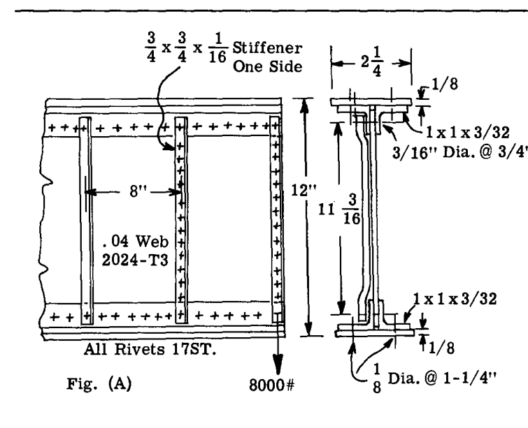

Fig. (A)

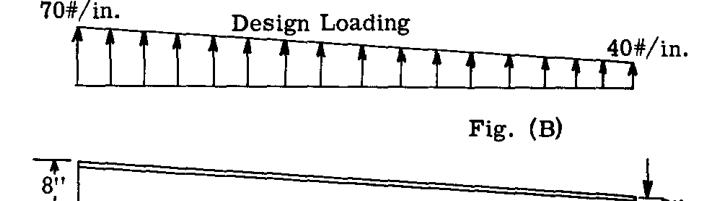

Fig. (B)

4. Fig. (C) は、シングルスパー翼梁の断面を示している。梁断面の以下の各部材の強度チェックを行え。(1) ウェブ、(2) ウェブ直立材。直立材の間隔は 8 インチであり、断面の設計せん断荷重は 35000 lb. である。ウェブ材料は 7075 alclad である。

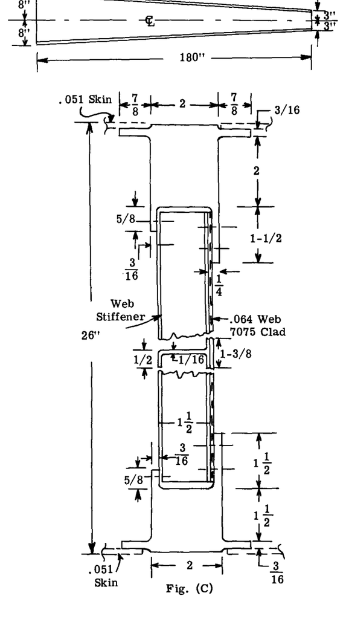

Fig. (C)

### 参考文献

1. H. Wagner, “Structures of Thin Sheet Metal, Their Design and Construction”, N.A.C.A. Memo. 490.
2. H. Wagner, “Flat Sheet Girder With Thin Metal Web.”
- Part I - N.A.C.A. Technical Memo. 604
- Part II - N.A.C.A. Technical Memo. 605
- Part III - N.A.C.A. Technical Memo. 606
3. Kuhn, Peterson, Levin:- A Summary of Diagonal Tension. Part 1. Methods of Analysis. N.A.C.A. T.N. 2661.
4. Kuhn, Peterson, Levin:- A Summary of Diagonal Tension. Part 2. Experimental Evidence. N.A.C.A. T.N. 2662.
5. N.A.C.A. T.N. 1347.
6. Ebner, H., The Strength of Shell Bodies. N.A.C.A. T.N. 838.
7. N.A.C.A. T.N. 1197.
8. N.A.C.A. T.N. 774.

[figure not shown]

Fig. C11.36

[figure not shown]

Fig. C11.37a

[figure not shown]

Fig. C11.37b

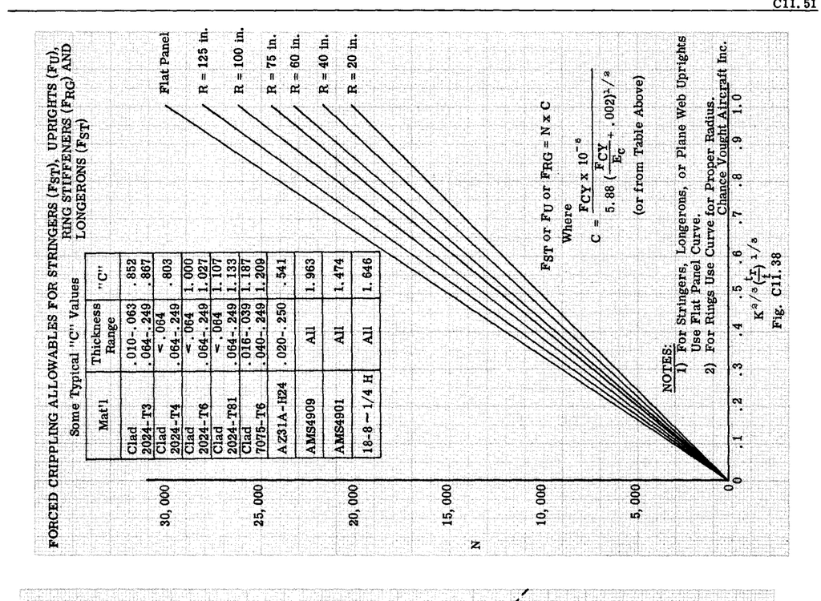

Fig. C11.38

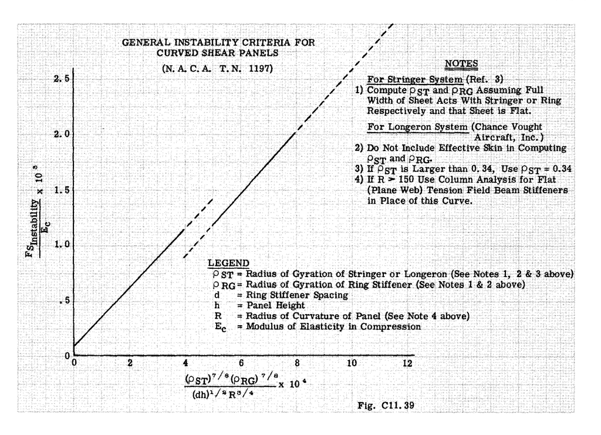

Fig. C11.39

[figure not shown]

Fig. C11.40

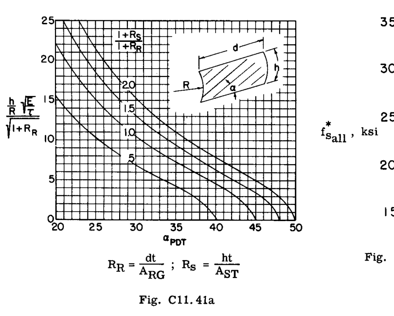

Fig. C11.41a

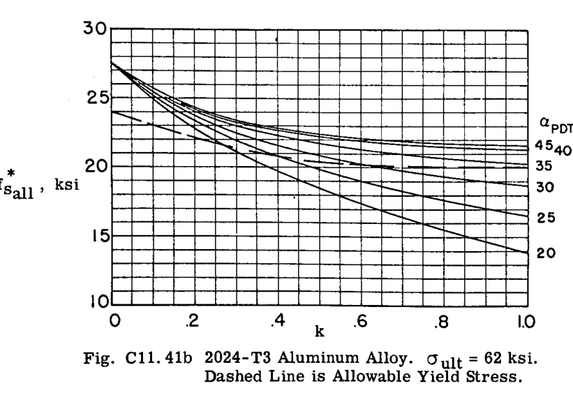

Fig. C11.41b

[figure not shown]

Fig. C11.41c

[figure not shown]

Fig. C11.41d

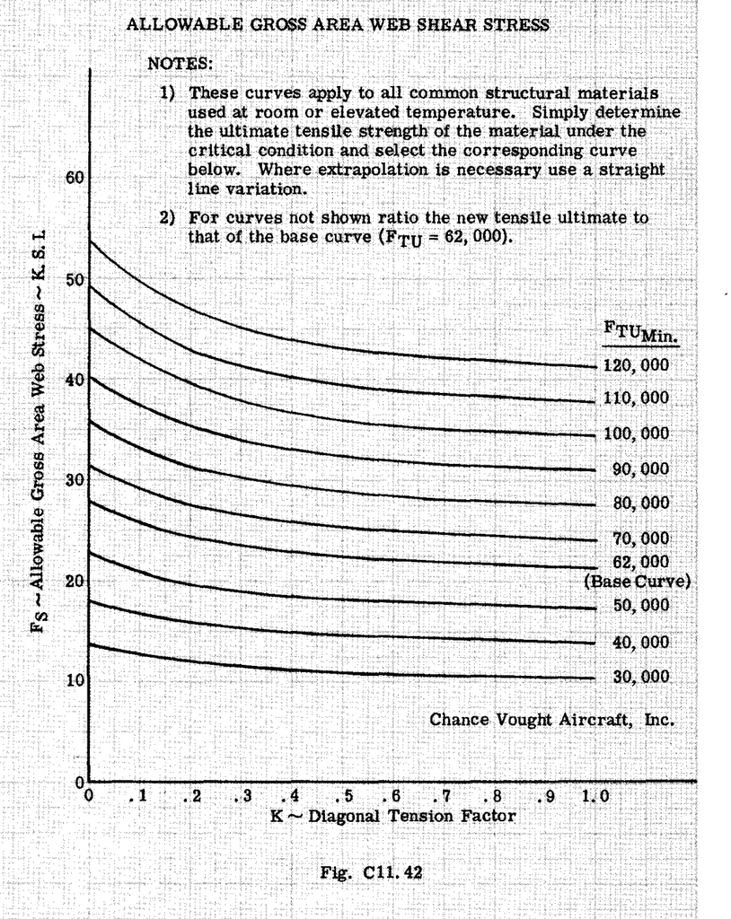

Fig. C11.42

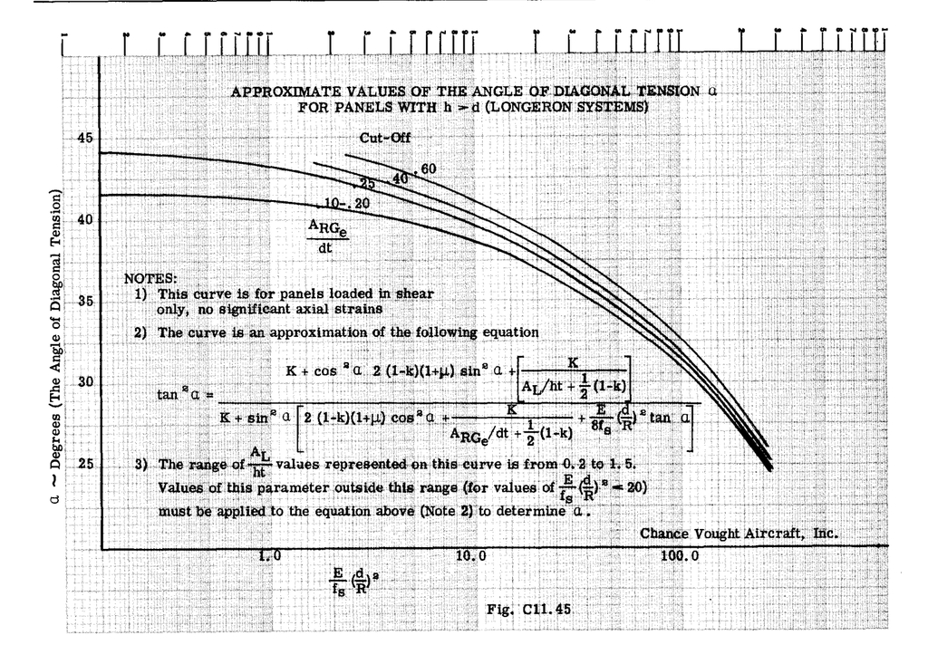

Fig. C11.45

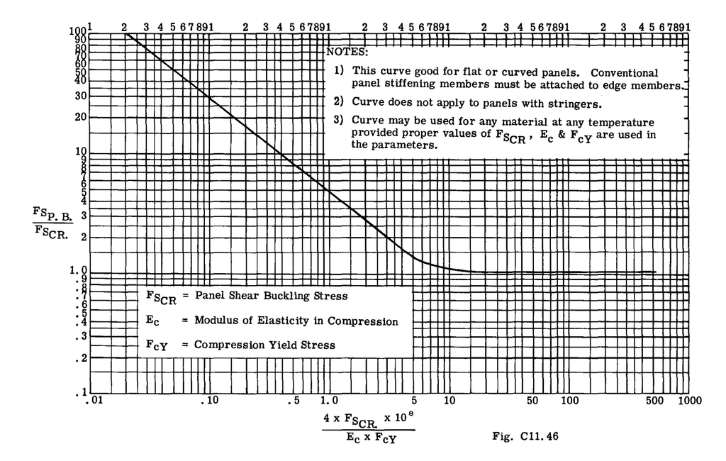

Fig. C11.46